# Multiple Comparisons: Packages and Functions

Eric R. Scott

```r
library(dplyr)
library(tidyr)
```

# Multiple Comparisons

Built in to R:

- Tukey Tests (`TukeyHSD()`)
- Pairwise t-tests with a variety of p-value adjustments (e.g. Bonferoni) (`pairwise.t.test()`)
- Adjusting p-values for specific compairisons (`t.test()`, extract p-values, pass vector of p-values to `p.adjust()`)

Other multiple comparisons:

- Dunn’s test—non-parametric mutliple comparisons following Kruskal Wallis (`dunn.test::dunn.test()`)
- Dunnet’s test—compares mutiple groups to a control (many complicated options)

Options for Dunnet’s test:

- `PMCMRplus::dunnettTest()`
- `multcomp::glht()` (https://stat.ethz.ch/pipermail/r-help/2015-June/429302.html)
- `DescTools::DunnettTest()` <– **This one is the best I think**

Intallation for all of these went smoothly for me.

# Tukey’s HSD

We need a better example data set with fewer levels. (like 3 or 4)

```r
chicks.aov <- aov(weight ~ feed, data = chickwts)
anova(chicks.aov)
```

```
Analysis of Variance Table

Response: weight
          Df Sum Sq Mean Sq F value    Pr(>F)
feed       5 231129   46226  15.365 5.936e-10 ***
Residuals 65 195556    3009
---
Signif. codes:  0 ‘***’ 0.001 ‘**’ 0.01 ‘*’ 0.05 ‘.’ 0.1 ‘ ’ 1
```

```r
TukeyHSD(chicks.aov)
```

```
  Tukey multiple comparisons of means
    95% family-wise confidence level

Fit: aov(formula = weight ~ feed, data = chickwts)

$feed
                           diff         lwr       upr     p adj
horsebean-casein    -163.383333 -232.346876 -94.41979 0.0000000
linseed-casein      -104.833333 -170.587491 -39.07918 0.0002100
meatmeal-casein      -46.674242 -113.906207  20.55772 0.3324584
soybean-casein       -77.154762 -140.517054 -13.79247 0.0083653
sunflower-casein       5.333333  -60.420825  71.08749 0.9998902
linseed-horsebean     58.550000  -10.413543 127.51354 0.1413329
meatmeal-horsebean   116.709091   46.335105 187.08308 0.0001062
soybean-horsebean     86.228571   19.541684 152.91546 0.0042167
sunflower-horsebean  168.716667   99.753124 237.68021 0.0000000
meatmeal-linseed      58.159091   -9.072873 125.39106 0.1276965
soybean-linseed       27.678571  -35.683721  91.04086 0.7932853
sunflower-linseed    110.166667   44.412509 175.92082 0.0000884
soybean-meatmeal     -30.480519  -95.375109  34.41407 0.7391356
sunflower-meatmeal    52.007576  -15.224388 119.23954 0.2206962
sunflower-soybean     82.488095   19.125803 145.85039 0.0038845
```

# Bonferroni adjustments

## all pairwise tests

```r
pairwise.t.test(chickwts$weight, chickwts$feed, p.adj = "none")
```

```
    Pairwise comparisons using t tests with pooled SD

data:  chickwts$weight and chickwts$feed

          casein  horsebean linseed meatmeal soybean
horsebean 2.1e-09 -         -       -        -
linseed   1.5e-05 0.01522   -       -        -
meatmeal  0.04557 7.5e-06   0.01348 -        -
soybean   0.00067 0.00032   0.20414 0.17255  -
sunflower 0.81249 8.2e-10   6.2e-06 0.02644  0.00030

P value adjustment method: none
```

## specific comparisons

The way I’ve done this is probably too complicated to be worth it.

```r
chickwts
```

| weight | feed |
| --- | --- |
| 179 | horsebean |
| 160 | horsebean |
| 136 | horsebean |
| 227 | horsebean |
| 217 | horsebean |
| 168 | horsebean |
| 108 | horsebean |
| 124 | horsebean |
| 143 | horsebean |
| 140 | horsebean |

[output cut: 61 more lines]

```r
# Spread data so you get each feed as a separate column.
chickwts.spread <- chickwts%>%
  group_by(feed) %>%
  mutate(ID = 1:n()) %>% # if you don't do this line, you get a "Duplicate identifiers" error
  spread(key = feed, value = weight) %>%
  select(-ID) # removes the ID column that we used just to get it to spread correctly
comp1 <- t.test(chickwts.spread$horsebean, chickwts.spread$soybean)
#p = 0.0001559
comp2 <- t.test(chickwts.spread$horsebean, chickwts.spread$meatmeal)
#p=0.0001054
ps <- c(comp1$p.value, comp2$p.value)
my.comps <- data.frame(comparison = c("horsebean - soybean", "horsebean - meatmeal"),
                       p.vals = ps) %>%
  mutate(p.adj = p.adjust(p.vals, "bonf"))
my.comps
```

| comparison | p.vals | p.adj |
| --- | --- | --- |
| horsebean - soybean | 0.0001558655 | 0.0003117310 |
| horsebean - meatmeal | 0.0001053843 | 0.0002107685 |

you can also use p.adjust outside of mutate

```r
p.adjust(c(0.0001559, 0.0001054), "bonf")
```

```
[1] 0.0003118 0.0002108
```

# Dunn’s Test

I remember last year there being some confusion about the p-value adjustment method. I think the book/slides don’t teach an optional adjustment method, but Dunn’s method was equivalent to bonferroni I think. Maybe.

`altp = TRUE` is super important, I think. From the help file:

“Reject Ho based on p ≤ α/2 (and in combination with p-value ordering for stepwise method options). If you prefer to work with p-values expressed as p-value = P(|Z| ≥ |z|) use the altp=TRUE option, and reject Ho based on p ≤ α (and in combination with p-value ordering for stepwise method options”

It’s not clear to me if you need to adjust p-values or not.

```r
library(dunn.test)
dunn.test(InsectSprays$count, InsectSprays$spray, altp = TRUE)
```

```
  Kruskal-Wallis rank sum test

data: x and group
Kruskal-Wallis chi-squared = 54.6913, df = 5, p-value = 0

                           Comparison of x by group
                                (No adjustment)
Col Mean-|
Row Mean |          A          B          C          D          E
---------+-------------------------------------------------------
       B |  -0.312733
         |     0.7545
       C |   4.774077   5.086811
         |    0.0000*    0.0000*
       D |   3.117565   3.430299  -1.656512
         |    0.0018*    0.0006*     0.0976
       E |   3.850535   4.163269  -0.923542   0.732969
         |    0.0001*    0.0000*     0.3557     0.4636
       F |  -0.405576  -0.092842  -5.179654  -3.523142  -4.256112
         |     0.6851     0.9260    0.0000*    0.0004*    0.0000*

alpha = 0.05
Reject Ho if p <= alpha
```

```r
# dunn.test(InsectSprays$count, InsectSprays$spray, altp = TRUE, method = "bonferroni")
```

# Dunnett’s Test

Let’s use chickwts and say soybean is the control.

## With `multcomp::glht()`

This one relies on factor levels to indicate which is the control.

```r
library(forcats) #for fool-proof manipulation of factor levels
data("chickwts")
```

1. Relevel so soybean is the control

```r
chickwts2 <- chickwts %>%
  mutate(feed = fct_relevel(feed, "soybean")) #move soybean to the first level
levels(chickwts$feed)
```

```
[1] "casein"    "horsebean" "linseed"   "meatmeal"  "soybean"   "sunflower"
```

```r
levels(chickwts2$feed)
```

```
[1] "soybean"   "casein"    "horsebean" "linseed"   "meatmeal"  "sunflower"
```

2. Run the `aov()` model

```r
chick.aov <- aov(weight ~ feed, data = chickwts2)
```

3. Do Dunnett’s test with `glht()`

```r
library(multcomp)
thing <- glht(chick.aov, linfct = mcp(feed = "Dunnett"))
summary(thing)
```

```
     Simultaneous Tests for General Linear Hypotheses

Multiple Comparisons of Means: Dunnett Contrasts


Fit: aov(formula = weight ~ feed, data = chickwts2)

Linear Hypotheses:
                         Estimate Std. Error t value Pr(>|t|)
casein - soybean == 0       77.15      21.58   3.576  0.00300 **
horsebean - soybean == 0   -86.23      22.71  -3.797  0.00157 **
linseed - soybean == 0     -27.68      21.58  -1.283  0.59425
meatmeal - soybean == 0     30.48      22.10   1.379  0.52600
sunflower - soybean == 0    82.49      21.58   3.823  0.00139 **
---
Signif. codes:  0 ‘***’ 0.001 ‘**’ 0.01 ‘*’ 0.05 ‘.’ 0.1 ‘ ’ 1
(Adjusted p values reported -- single-step method)
```

**Pros**: nice output **Cons**: Relies on factor levels to determine control. A lot of the code is “just because that’s how you do it”. Not intuitive. What is linfct? what is mcp? Why does feed *equal* “Dunnett”?? Gotta run `summary()` to get p-values?

## With `DescTools::DunnettTest()`

```r
library(DescTools)
DunnettTest(weight ~ feed, data = chickwts, control = "soybean")
```

```
  Dunnett's test for comparing several treatments with a control :
    95% family-wise confidence level

$soybean
                       diff     lwr.ci    upr.ci   pval
casein-soybean     77.15476   21.23661 133.07291 0.0031 **
horsebean-soybean -86.22857 -145.08073 -27.37642 0.0016 **
linseed-soybean   -27.67857  -83.59672  28.23958 0.5943
meatmeal-soybean   30.48052  -26.78991  87.75095 0.5260
sunflower-soybean  82.48810   26.56994 138.40625 0.0014 **

---
Signif. codes:  0 '***' 0.001 '**' 0.01 '*' 0.05 '.' 0.1 ' ' 1
```

**Pros:** Looks just like `aov()` or `t.test()`. Supply the control level directly. **Cons:** Not as flexible as `glht()` (only does Dunnett’s Test)

## With `PMCMRplus::dunnettTest()`

```r
library(PMCMRplus)
```

```r
dunnettTest(weight ~ feed, data = chickwts2) %>% summary()
```

```
    Pairwise comparisons using Dunnett's-test for multiple
                         comparisons with one control

data: weight by feed
alternative hypothesis: two.sided
P value adjustment method: single-step
H0
```

|  | t value | Pr(>\|t\|) |  |
| --- | --- | --- | --- |
| casein - soybean == 0 | 3.576 | 0.0030925 | ** |
| horsebean - soybean == 0 | -3.797 | 0.0015310 | ** |
| linseed - soybean == 0 | -1.283 | 0.5942596 |  |
| meatmeal - soybean == 0 | 1.379 | 0.5259407 |  |
| sunflower - soybean == 0 | 3.823 | 0.0014226 | ** |

```
---
Signif. codes: 0 ‘***’ 0.001 ‘**’ 0.01 ‘*’ 0.05 ‘.’ 0.1 ‘ ’ 1
```

**Pros:** Output is a data frame. Simpler than `glht` **Cons:** Relies on factor levels for identifying control.

# Plotting Results of Multiple Comparisons

## Step 1:

Stare at the test output, decide what the letters are, make a vector.

```r
tooth.aov <- aov(len~factor(dose), data = ToothGrowth)
anova(tooth.aov)
```

```
Analysis of Variance Table

Response: len
             Df Sum Sq Mean Sq F value    Pr(>F)
factor(dose)  2 2426.4  1213.2  67.416 9.533e-16 ***
Residuals    57 1025.8    18.0
---
Signif. codes:  0 ‘***’ 0.001 ‘**’ 0.01 ‘*’ 0.05 ‘.’ 0.1 ‘ ’ 1
```

```r
TukeyHSD(tooth.aov)
```

```
  Tukey multiple comparisons of means
    95% family-wise confidence level

Fit: aov(formula = len ~ factor(dose), data = ToothGrowth)

$`factor(dose)`
        diff       lwr       upr    p adj
1-0.5  9.130  5.901805 12.358195 0.00e+00
2-0.5 15.495 12.266805 18.723195 0.00e+00
2-1    6.365  3.136805  9.593195 4.25e-05
```

Easy example!

a, b, c

```r
sig.letters <- c("a", "b", "c")
```

## Plotting Options

```r
library(ggplot2)
```

### Boxplot with letters

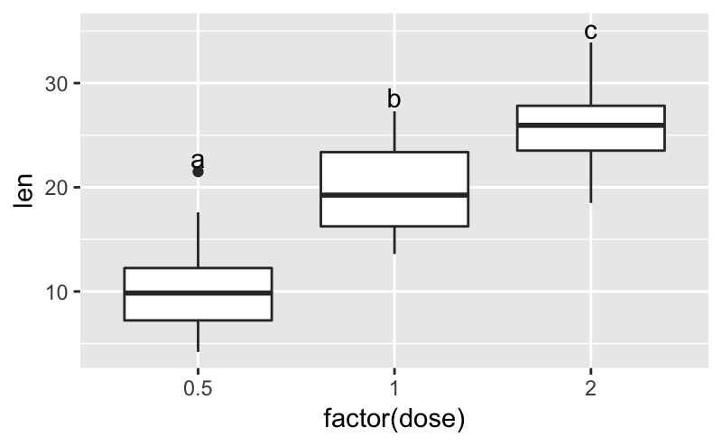

```r
p <- ggplot(ToothGrowth, aes(x = factor(dose), y = len))
p +
  geom_boxplot() +
  stat_summary(geom = "text",
               label = sig.letters, #passed to geom_text()
               fun.y = max, #what function to use to summarize the data, ToothGrowth to get y-values?
               position = position_nudge(y = 1.3)) #nudges the letters slightly above max(len)
```

### Jitter plot with means and SEM and letters nudged to the side?

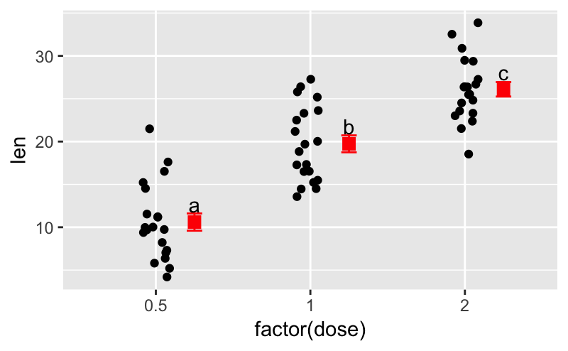

```r
p + geom_jitter(width = 0.1) +
  stat_summary(geom = "point", fun.y = mean, color = "red", shape = "square", size = 3, position = position_nudge(x = 0.25)) +
  stat_summary(geom = "errorbar", fun.data = mean_se, color = "red", position = position_nudge(x = 0.25), width = 0.1) +
  stat_summary(geom = "text", label = sig.letters, fun.y = mean, position = position_nudge(x = 0.25, y = 2))
```

### Violin plots with letters??